# MTH6139 Time Series

Coursework 1 – S&P 500 Forecast

Rayyan Hussein Ahmed Osman - 230637665

12/03/2026

# Introduction

The focus of this report will be about analysing historical data from the **S&P500 index**, particularly, historical prices of this index which I will obtain from **FRED**, which is maintained by the Federal Reserve Bank of St. Louis.

I aim to explore this data by applying time series forecasting techniques to create statistical forecasts for future index behaviour.

## Why The S&P500?

The **S&P500 index** was chosen because it is widely used as a benchmark for the US equity market. It is also an index I am familiar with from following major market indices such as **Nasdaq** and **S&P500**.

Also, as an aspiring Quant, I wish to use a dataset that is meaningful in finance and quantitative trading since I will be adding this report to my CV.

# Getting to Know the Data

The data I optained from **FRED** represents the daily closing values of the index, typically recorded at 4:00pm Eastern time. The index includes 500 companies that are largely traded and covers around 75% of total market capitalisation.

Additionally, the series that will be used in the analysis embodies the **price index**, meaning it won’t include dividend payments.

## What the Dataset Looks Like

Here we will observe the dataset from the data folder, but before we do that we must first **import** the data, which we will as follows:

```r
sp500 <- read.csv("data/sp500.csv")
```

Now we are ready to see what the data looks like…

```r
head(sp500)
```

```
##   observation_date   SP500
## 1       2016-03-14 2019.64
## 2       2016-03-15 2015.93
## 3       2016-03-16 2027.22
## 4       2016-03-17 2040.59
## 5       2016-03-18 2049.58
## 6       2016-03-21 2051.60
```

The head function shows us the **first 6 observations** and we see that the file contains observation_date which is the date and SP500 which shows the value of the **S&P500** on that date.

We can also use the str function to see what the structure of the data is:

```r
str(sp500)
```

```
## 'data.frame':    2610 obs. of  2 variables:
##  $ observation_date: chr  "2016-03-14" "2016-03-15" "2016-03-16" "2016-03-17" ...
##  $ SP500           : num  2020 2016 2027 2041 2050 ...
```

We see that there are a total of **2610 observations** across the 2 variables. The index values are stored as numeric data, meanwhile the date variable is currently stored as a character string. Later we will convert it into a proper data format.

## Cleaning the Data

Now that we have extracted the data from the **SP500** file, the observation data needs to be converted into its appropriate format for time-series modelling.

Firstly we will convert the dates into a date format:

```r
sp500$observation_date <- as.Date(sp500$observation_date)
```

Now the dates are in its appropriate format. Additionally, we need to review the data by ensuring that all dates each have a corresponding price.

```r
sum(is.na(sp500))
```

```
## [1] 95
```

Following this, it is clear that there are **95 dates** in the file which do not have a corresponding price, this could be because of weekends, gaps in the series or data alignment issues.

To rectify this, we must remove it by doing the following:

```r
sp500 <- na.omit(sp500)
sum(is.na(sp500))
```

```
## [1] 0
```

Now the data is clean and there is no empty prices in the dataset.

# Exploring the Data

Before we apply the Prophet model, let’s observe the time series to understand its behaviour.

## How has the Index Changes Over Time?

The distribution of the **S&P500 index** over a decade is shown below:

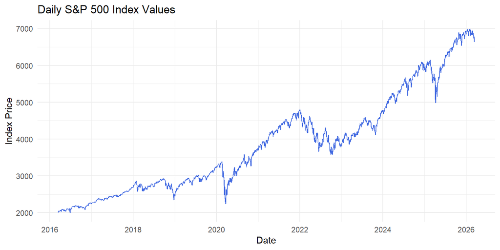

```r
ggplot(sp500, aes(x = observation_date, y = SP500)) +
  geom_line(color = "royalblue") +
  labs(
    title = "Daily S&P 500 Index Values",
    x = "Date",
    y = "Index Price"
  ) +
  theme_minimal()
```

The plot above is a nice visual of the daily close price action of the index over the last 10 years. We notice that the index has been rising in price over time with notable ‘dumps’ due to financial stress, such as COVID which resulted in a dump in around 2020.

## Daily Changes in the Index

To better understand short-term movements in the index, the daily changes in the **S&P500** can be examined using a plot of daily returns. These returns are calculated as the difference between consecutive observations, and looks as follows:

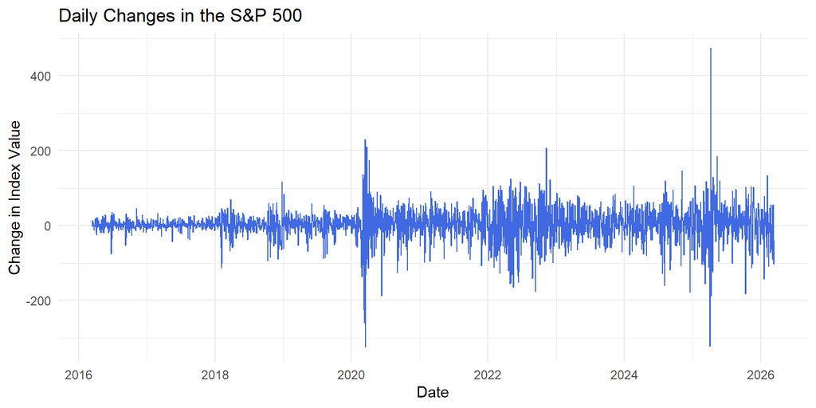

```r
returns <- diff(sp500$SP500)

ggplot(data.frame(
  date = sp500$observation_date[-1],
  returns = returns
), aes(x = date, y = returns)) +
  geom_line(color = "royalblue") +
  labs(
    title = "Daily Changes in the S&P 500",
    x = "Date",
    y = "Change in Index Value"
  ) +
  theme_minimal()
```

From the plot above, we can infer that there is increased market volatility compared to the earlier years, 2016 to 2020, we see that as price increases, market volatility also increases. Also, we see points of very high index values, which are where there was drastic price changes, such as during COVID at around 2020.

# Forecasting the S&P500

Now that we have explored the behaviour of the data, the next stage is using the prophet model to generate predictions of future values of the **S&P500**.

Before that, we need to reallocate the data into a dataframe for prophet use:

```r
prophet_data <- data.frame(
  ds = sp500$observation_date,
  y = sp500$SP500
)
```

Now we are ready to load the prophet library and fit the dataset into the prophet model:

```r
library(prophet)
model <- prophet(prophet_data)
```

We then create a year of future dates on the daily time frame and this is used to generate predictions for it:

```r
future <- make_future_dataframe(model, periods = 365)
forecast <- predict(model, future)
```

## Where is the Market Heading?

Now that we have the future dates and the future prices from the predict function, we can now display the forcasted prices with the current historical data using the plot function:

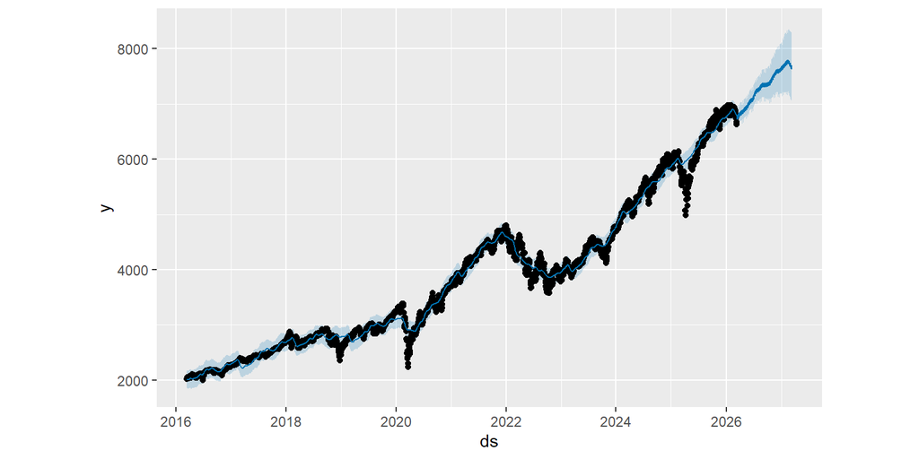

```r
plot(model, forecast)
```

This demonstrates overall upward trend for the future dates that we created using the forcasted values.

## Enquiring Trend/Seasonal Tendencies

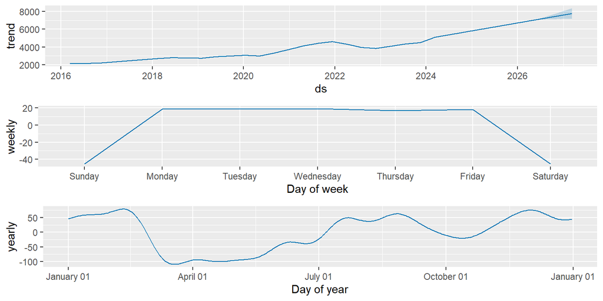

```r
prophet_plot_components(model, forecast)
```

The **trend plot** above shows a clear upward movement in the S&P 500 over time. This reflects the long-term growth we saw in the time series analysis.

Additionally, the **weekly plot** appears to have little meaning, which is normal because financial markets are not open on the weekends.

Lastly, the **yearly plot** shows clear fluctuations but there isn’t a strong pattern. From this, it is clear that for the **S&P500**, overall trend is a more dominant feature.

# Key Takeaways

The **S&P500** shows a upward trend over time with dips during periods of market stress. The daily changes also highlight how volatile the market can be in the short term.

The Prophet model captures the overall direction of the index well but it struggles to reflect these short-term fluctuations. This shows that while forecasting can give a useful general outlook it is less reliable for predicting daily movements in financial markets.

# References

https://fred.stlouisfed.org/ - Where I got the **S&P500** historical data

https://facebook.github.io/prophet/ https://ggplot2.tidyverse.org/